# Assignment 2 - CSCN8000 Artificial Intelligence Algorithms and Mathematics

Zhimin (Benny) Xiong 9067935

## Description

The assignment is to use the [heart disease dataset](https://www.kaggle.com/fedesoriano/heart-failure-prediction) to do following:

1. Consider the heart disease dataset in pandas dataframe
2. Remove outliers using mean,median,Z score.
3. Convert text columns to numbers using label encoding and one hot encoding
4. Apply scaling
5. Build a machine learning classification model using support vector machine. Demonstrate the standalone model as well as Bagging model and include observations about the oerformance
6. Now use decision tree classifier. Use standalone model as well as Bagging and check if you notice any difference in performance
7. Comparing performance of svm and decision tree classifier figure out where it makes most sense to use bagging and why.

## Imports

```python
import pandas as pd
import numpy as np
import seaborn as sns
import matplotlib.pyplot as plt
import math

from scipy.stats import zscore
from sklearn.preprocessing import LabelEncoder, StandardScaler
from sklearn.svm import SVC
from sklearn.ensemble import BaggingClassifier
from sklearn.tree import DecisionTreeClassifier
from sklearn.model_selection import train_test_split, cross_val_score
from sklearn.metrics import accuracy_score, classification_report
```

## Load data

```python
# read heart csv file from Reources folder
df = pd.read_csv("../Resources/heart.csv")
# display top 5 rows
df.head()
```

|  | Age | Sex | ChestPainType | RestingBP | Cholesterol | FastingBS | RestingECG | MaxHR | ExerciseAngina | Oldpeak | ST_Slope | HeartDisease |
| --- | --- | --- | --- | --- | --- | --- | --- | --- | --- | --- | --- | --- |
| 0 | 40 | M | ATA | 140 | 289 | 0 | Normal | 172 | N | 0.0 | Up | 0 |
| 1 | 49 | F | NAP | 160 | 180 | 0 | Normal | 156 | N | 1.0 | Flat | 1 |
| 2 | 37 | M | ATA | 130 | 283 | 0 | ST | 98 | N | 0.0 | Up | 0 |
| 3 | 48 | F | ASY | 138 | 214 | 0 | Normal | 108 | Y | 1.5 | Flat | 1 |
| 4 | 54 | M | NAP | 150 | 195 | 0 | Normal | 122 | N | 0.0 | Up | 0 |

## Exploratory data analysis

```python
# data information
df.info()
```

```
<class 'pandas.core.frame.DataFrame'>
RangeIndex: 918 entries, 0 to 917
Data columns (total 12 columns):
 #   Column          Non-Null Count  Dtype
---  ------          --------------  -----
 0   Age             918 non-null    int64
 1   Sex             918 non-null    object
 2   ChestPainType   918 non-null    object
 3   RestingBP       918 non-null    int64
 4   Cholesterol     918 non-null    int64
 5   FastingBS       918 non-null    int64
 6   RestingECG      918 non-null    object
 7   MaxHR           918 non-null    int64
 8   ExerciseAngina  918 non-null    object
 9   Oldpeak         918 non-null    float64
 10  ST_Slope        918 non-null    object
 11  HeartDisease    918 non-null    int64
dtypes: float64(1), int64(6), object(5)
memory usage: 86.2+ KB
```

```python
# data statistics
df.describe()
```

|  | Age | RestingBP | Cholesterol | FastingBS | MaxHR | Oldpeak | HeartDisease |
| --- | --- | --- | --- | --- | --- | --- | --- |
| count | 918.000000 | 918.000000 | 918.000000 | 918.000000 | 918.000000 | 918.000000 | 918.000000 |
| mean | 53.510893 | 132.396514 | 198.799564 | 0.233115 | 136.809368 | 0.887364 | 0.553377 |
| std | 9.432617 | 18.514154 | 109.384145 | 0.423046 | 25.460334 | 1.066570 | 0.497414 |
| min | 28.000000 | 0.000000 | 0.000000 | 0.000000 | 60.000000 | -2.600000 | 0.000000 |
| 25% | 47.000000 | 120.000000 | 173.250000 | 0.000000 | 120.000000 | 0.000000 | 0.000000 |
| 50% | 54.000000 | 130.000000 | 223.000000 | 0.000000 | 138.000000 | 0.600000 | 1.000000 |
| 75% | 60.000000 | 140.000000 | 267.000000 | 0.000000 | 156.000000 | 1.500000 | 1.000000 |
| max | 77.000000 | 200.000000 | 603.000000 | 1.000000 | 202.000000 | 6.200000 | 1.000000 |

**There is no missing data. But need to scale and check for outliers.**

## Remove outliers

```python
# A class takes a DataFrame and a list of features as parameters, and creates box plots for each feature to help visualize outliers.
class BoxPlotter:
    def __init__(self, df, features):
        """
        df: pandas DataFrame
        features: list of column names (numerical) to plot
        """
        self.df = df
        self.features = features

    def plot(self, cols=3, figsize_scale=(5, 4)):
        """
        cols: number of columns in subplot grid
        figsize_scale: tuple controlling figure size scaling (width, height)
        """
        n = len(self.features)
        rows = math.ceil(n / cols)

        plt.figure(figsize=(cols * figsize_scale[0], rows * figsize_scale[1]))

        for i, feature in enumerate(self.features, 1):
            if feature not in self.df.columns:
                continue

            plt.subplot(rows, cols, i)
            sns.boxplot(y=self.df[feature])
            plt.title(feature)

        plt.tight_layout()
        plt.show()
```

```python
# List of features to check for outliers
# Exclude categorical features ('Sex', 'ChestPainType', 'FastingBS', 'RestingECG', 'ExerciseAngina', 'ST_Slope')
features = ['Age', 'RestingBP', 'Cholesterol', 'MaxHR', 'Oldpeak']
```

### Visualization before removing outliers

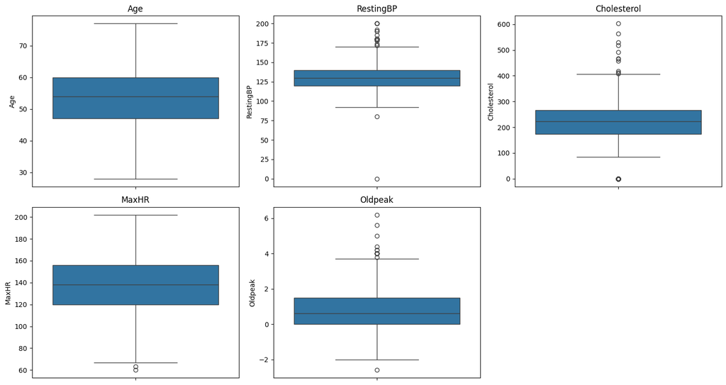

```python
# plot
plotter = BoxPlotter(df, features)
plotter.plot(cols=3)
```

### Remove outliers

```python
# A class that accepts a list of features and removes outliers from a DataFrame using mean, median, or Z-score method
class OutlierRemover:
    def __init__(self, methods=['mean', 'median', 'zscore']):
        self.methods = methods

    def remove_outliers(self, df, features, z_thresh=3):
        """
        df: pandas DataFrame
        features: list of numeric feature names
        z_thresh: threshold for z-score (only used for zscore method)
        returns: DataFrame with outliers removed
        """
        df_clean = df.copy()
        all_outlier_indices = set()

        for method in self.methods:
            for feature in features:
                if feature not in df_clean.columns:
                    continue

                if method == 'mean':
                    outlier_idx = self._get_outliers_by_mean(df_clean, feature)
                elif method == 'median':
                    outlier_idx = self._get_outliers_by_median(df_clean, feature)
                elif method == 'zscore':
                    outlier_idx = self._get_outliers_by_zscore(df_clean, feature, z_thresh)

                all_outlier_indices.update(outlier_idx)

        # Drop all rows with any outlier in any method/feature
        df_clean = df_clean.drop(index=all_outlier_indices)
        return df_clean

    def _get_outliers_by_mean(self, df, feature):
        mean = df[feature].mean()
        std = df[feature].std()
        lower = mean - 3 * std
        upper = mean + 3 * std
        return df[(df[feature] < lower) | (df[feature] > upper)].index

    def _get_outliers_by_median(self, df, feature):
        median = df[feature].median()
        mad = np.median(np.abs(df[feature] - median))
        lower = median - 3 * mad
        upper = median + 3 * mad
        return df[(df[feature] < lower) | (df[feature] > upper)].index

    def _get_outliers_by_zscore(self, df, feature, threshold):
        z_scores = zscore(df[feature].dropna())
        abs_z_scores = np.abs(z_scores)
        mask = abs_z_scores >= threshold
        return df[feature].dropna().index[mask]
```

```python
# Initialize the OutlierRemover class
remover = OutlierRemover()
# Clean DataFrame
df_clean = remover.remove_outliers(df, features)
```

### Visualization after outliers removed

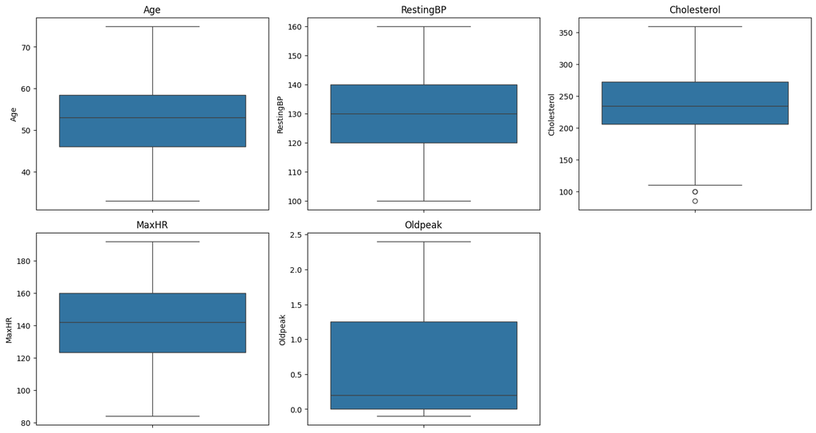

```python
# Plot
plotter = BoxPlotter(df_clean, features)
plotter.plot(cols=3)
```

## Label encoding and one hot encoding

- Categorical features with text data ('Sex', 'ChestPainType', 'RestingECG', 'ExerciseAngina', 'ST_Slope') are good candidates for label encoding and one hot encoding.
- Label encoding is better for ordinal data with many unique values, e.g. 'ChestPainType', 'RestingECG', and 'ST_Slope'.
- One hot encoding is better for nominal data and creates a new binary column for each category. Which makes it ideal for 'Sex' and 'ExerciseAngina'.

### Label encoding

```python
# Encode specified categorical features using LabelEncoder.
def Label_encode_categorical_features(df, features):
    df_encoded = df.copy()

    for feature in features:
        if feature in df_encoded.columns:
            le = LabelEncoder()
            df_encoded[feature] = le.fit_transform(df_encoded[feature].astype(str))

    return df_encoded

# label encoding features 'ChestPainType', 'RestingECG', 'ST_Slope'
df_encoded = Label_encode_categorical_features(df_clean, ['ChestPainType', 'RestingECG', 'ST_Slope'])
# display top 5 rows of df_encoded
df_encoded.head()
```

|  | Age | Sex | ChestPainType | RestingBP | Cholesterol | FastingBS | RestingECG | MaxHR | ExerciseAngina | Oldpeak | ST_Slope | HeartDisease |
| --- | --- | --- | --- | --- | --- | --- | --- | --- | --- | --- | --- | --- |
| 0 | 40 | M | 1 | 140 | 289 | 0 | 1 | 172 | N | 0.0 | 2 | 0 |
| 1 | 49 | F | 2 | 160 | 180 | 0 | 1 | 156 | N | 1.0 | 1 | 1 |
| 2 | 37 | M | 1 | 130 | 283 | 0 | 2 | 98 | N | 0.0 | 2 | 0 |
| 3 | 48 | F | 0 | 138 | 214 | 0 | 1 | 108 | Y | 1.5 | 1 | 1 |
| 4 | 54 | M | 2 | 150 | 195 | 0 | 1 | 122 | N | 0.0 | 2 | 0 |

### One hot encoding

```python
# One-hot encode the specified categorical features.
def one_hot_encode_features(df, features):
    df_encoded = pd.get_dummies(df, columns=features, drop_first=True)
    return df_encoded

# one hot encoding features 'Sex' and 'ExerciseAngina'
df_encoded = one_hot_encode_features(df_encoded, ['Sex', 'ExerciseAngina'])
# display top 5 rows of df_encoded
df_encoded.head()
```

|  | Age | ChestPainType | RestingBP | Cholesterol | FastingBS | RestingECG | MaxHR | Oldpeak | ST_Slope | HeartDisease | Sex_M | ExerciseAngina_Y |
| --- | --- | --- | --- | --- | --- | --- | --- | --- | --- | --- | --- | --- |
| 0 | 40 | 1 | 140 | 289 | 0 | 1 | 172 | 0.0 | 2 | 0 | True | False |
| 1 | 49 | 2 | 160 | 180 | 0 | 1 | 156 | 1.0 | 1 | 1 | False | False |
| 2 | 37 | 1 | 130 | 283 | 0 | 2 | 98 | 0.0 | 2 | 0 | True | False |
| 3 | 48 | 0 | 138 | 214 | 0 | 1 | 108 | 1.5 | 1 | 1 | False | True |
| 4 | 54 | 2 | 150 | 195 | 0 | 1 | 122 | 0.0 | 2 | 0 | True | False |

## Apply scaling

```python
# Apply StandardScaler to specified numeric features.
def scale_numeric_features(df, features):
    scaler = StandardScaler()
    df_scaled = df.copy()

    df_scaled[features] = scaler.fit_transform(df[features])

    return df_scaled


# Fit the scaler to the data and transform it
df_scaled = scale_numeric_features(df_encoded, ['Age', 'RestingBP', 'Cholesterol', 'MaxHR', 'Oldpeak'])
# Display top 5 rows
df_scaled.head()
```

|  | Age | ChestPainType | RestingBP | Cholesterol | FastingBS | RestingECG | MaxHR | Oldpeak | ST_Slope | HeartDisease | Sex_M | ExerciseAngina_Y |
| --- | --- | --- | --- | --- | --- | --- | --- | --- | --- | --- | --- | --- |
| 0 | -1.396930 | 1 | 0.669769 | 1.060636 | 0 | 1 | 1.272080 | -0.855361 | 2 | 0 | True | False |
| 1 | -0.390676 | 2 | 2.093760 | -1.210615 | 0 | 1 | 0.608790 | 0.476956 | 1 | 1 | False | False |
| 2 | -1.732349 | 1 | -0.042227 | 0.935613 | 0 | 2 | -1.795636 | -0.855361 | 2 | 0 | True | False |
| 3 | -0.502482 | 0 | 0.527370 | -0.502152 | 0 | 1 | -1.381080 | 1.143115 | 1 | 1 | False | True |
| 4 | 0.168354 | 2 | 1.381765 | -0.898058 | 0 | 1 | -0.800701 | -0.855361 | 2 | 0 | True | False |

## Data for model training

```python
# Split the dataset
X = df_scaled.drop(columns=['HeartDisease'])
y = df_scaled['HeartDisease']
```

## Support vector machine classifier

### Standalone SVM

```python
svm_clf = SVC(kernel='rbf', C=1.0, gamma='scale', random_state=42)
```

### Bagging with SVM Base Estimator

```python
bagging_svm = BaggingClassifier(estimator=SVC(kernel='rbf', C=1.0, gamma='scale'),
                                n_estimators=10,
                                max_samples=0.8,
                                bootstrap=True,
                                random_state=42,
                                n_jobs=-1)
```

### Performance comparison

```python
# Cross-validation scores
svm_scores = cross_val_score(svm_clf, X, y, cv=5, scoring='accuracy')
svm_f1 = cross_val_score(svm_clf, X, y, cv=5, scoring='f1_weighted')

bagging_scores = cross_val_score(bagging_svm, X, y, cv=5, scoring='accuracy')
bagging_f1 = cross_val_score(bagging_svm, X, y, cv=5, scoring='f1_weighted')

# Combine results
cv_comparison_svm = pd.DataFrame({
    'Model': ['Standalone SVM', 'Bagging SVM'],
    'CV Mean Accuracy': [np.mean(svm_scores), np.mean(bagging_scores)],
    'CV Std Dev': [np.std(svm_scores), np.std(bagging_scores)],
    'CV Mean F1 Score': [np.mean(svm_f1), np.mean(bagging_f1)],
    'CV Std F1 Score': [np.std(svm_f1), np.std(bagging_f1)],
})
cv_comparison_svm.round(6)
```

|  | Model | CV Mean Accuracy | CV Std Dev | CV Mean F1 Score | CV Std F1 Score |
| --- | --- | --- | --- | --- | --- |
| 0 | Standalone SVM | 0.828479 | 0.074575 | 0.826871 | 0.075968 |
| 1 | Bagging SVM | 0.828533 | 0.064340 | 0.826687 | 0.065656 |

### Observations

- Standalone SVM and Bagging SVM models have almost the same accuracy and F1 scores.
- Bagging SVM model has lower standard deviation of accuracy and F1 scores, which means it's more consistent across different subsets of the data than Standalone SVM.

## Decision tree classifier

### Standalone

```python
dt_clf = DecisionTreeClassifier(random_state=42)
```

### Bagging

```python
bagging_dt = BaggingClassifier(
    estimator=DecisionTreeClassifier(random_state=42),
    n_estimators=10,
    max_samples=0.8,
    bootstrap=True,
    random_state=42,
    n_jobs=-1
)
```

### Performance comparison

```python
# Cross-validation scores (5-fold)
dt_acc = cross_val_score(dt_clf, X, y, cv=5, scoring='accuracy')
dt_f1 = cross_val_score(dt_clf, X, y, cv=5, scoring='f1_weighted')

bagging_acc = cross_val_score(bagging_dt, X, y, cv=5, scoring='accuracy')
bagging_f1 = cross_val_score(bagging_dt, X, y, cv=5, scoring='f1_weighted')

# Combine results into a DataFrame
cv_comparison_dt = pd.DataFrame({
    'Model': ['Decision Tree', 'Bagging (Decision Tree)'],
    'CV Mean Accuracy': [np.mean(dt_acc), np.mean(bagging_acc)],
    'CV Std Dev': [np.std(dt_acc), np.std(bagging_acc)],
    'CV Mean F1 Score': [np.mean(dt_f1), np.mean(bagging_f1)],
    'CV Std F1 Score': [np.std(dt_f1), np.std(bagging_f1)],
})
cv_comparison_dt.round(6)
```

|  | Model | CV Mean Accuracy | CV Std Dev | CV Mean F1 Score | CV Std F1 Score |
| --- | --- | --- | --- | --- | --- |
| 0 | Decision Tree | 0.772510 | 0.061513 | 0.771738 | 0.062072 |
| 1 | Bagging (Decision Tree) | 0.818629 | 0.060054 | 0.815499 | 0.062848 |

### Observations

- Baggind Decision Tree model has better accuracy and F1 scores than the Standalone Decision Tree model.
- Both models have similar standard deviation of the accuracy and F1 scores.

## Comparing performance of svm and decision tree classifier

```python
# Merge the performance dataframes of svm and decision tree
df_merged = pd.concat([cv_comparison_svm, cv_comparison_dt], ignore_index=True)
df_merged
```

|  | Model | CV Mean Accuracy | CV Std Dev | CV Mean F1 Score | CV Std F1 Score |
| --- | --- | --- | --- | --- | --- |
| 0 | Standalone SVM | 0.828479 | 0.074575 | 0.826871 | 0.075968 |
| 1 | Bagging SVM | 0.828533 | 0.064340 | 0.826687 | 0.065656 |
| 2 | Decision Tree | 0.772510 | 0.061513 | 0.771738 | 0.062072 |
| 3 | Bagging (Decision Tree) | 0.818629 | 0.060054 | 0.815499 | 0.062848 |

- Support vector machine (SVM) classifier, both standalone and bagging, has better performance than Decision Tree classifier (standalone and bagging).
- Bagging with SVM has little effect on the performance, but it improve the model's consistency. This is because bagging helps unstable models, but SVMs are generally stable. The model is not very sensitive to small data changes, so each bagged model is similar.
- Bagging with Decision Tree improves performance and still keeps the model's consistency. This is because Decision Trees are high-variance models, meaning small changes in data can lead to very different trees. Bagging trains multiple trees on random subsets of the data and averages their predictions, smoothing out those wild changes.